# House Sale Prices from 2007 to 2019: Time Series Forecasting with Decomposition

Josie Gallop

2024-11-18

# 1 Introduction

For this project, we will be creating a Time Series. We will be working on decomposing this time series and forecasting with decomposing. The data set I found for this project looks at the sale prices for homes that have been sold from 2007 to 2019 in the United States. This data set includes the sale prices of these various homes over this course of 12 years. We will use this data set to create a time series to analyze these home sale prices along with any sort of trends that there may be. We will work on decomposing this time series of the home sale prices and will use forecasting with decomposing for this analysis of the time series data.

## 1.1 Data Description

I found this data set on kaggle.com on the following webpage: https://www.kaggle.com/datasets/htagholdings/property-sales?select=raw_sales.csv

This data set looks at the sale prices for homes that have been recorded from 2007 to 2019. The first observation was collected on February 6, 2007, and the final observation in the data set was collected on July 26, 2019. The sale prices are given in US dollars, and were collected to look at the trends amongst the sale prices of homes in this particular region.

We will read in the data set from Github and we will call it “home”.

```r
home <- read.csv("https://raw.githubusercontent.com/JosieGallop/STA321/refs/heads/main/dataset/raw_sales.csv")
```

The original data set contains multiple variables looking at things such as the postcode of the house, the type of property it is, and the number of bedrooms in the house. However, for this project, we are just looking at creating a time series with the variable of house sale prices. So, we will create a new data set called “home1” with just the variables of datesold and price. Additionally, we will create a new data set “data.home” which includes only the most recent 150 observations of the data. We will use this data set with only the most recent 150 observations for our time series.

```r
home1 <- data.frame(home$datesold, home$price)
n.row = dim(home1)[1]
data.home = home1[(n.row-150):n.row, ]
```

Now, we have a data set “data.home” with just the most recent 150 observations of the sale prices of the houses.

## 1.2 Variables

The two variables which we are interested in looking at for this time series project include:

- datesold: The date on which the house was sold. This is given in the format of year-month-day time”, for example, “2007-02-07 00:00:00”. This is a variable used for identifying each observation of house sales.
- price: The price for which a house was sold for, given in US dollars. This is a quantitative, numerical variable which we are interested in observing the trends of over time.

We will create a time series which observed and analyzes the trends and patterns seen in the sales price of homes over time.

# 2 Exploratory Data Analysis

Before we create our time series object, let’s ensure that there are no missing values in our data set of the last 150 observations, “data.home”.

```r
colSums(is.na(data.home))
```

```
home.datesold    home.price
            0             0
```

As we can see, there are zero missing values in our data set, so that means we do not have to worry about filling in any missing observations. We can proceed with creating our time series object.

## 2.1 Time Series Plot

Now, let’s create a time series object from our data and plot it to help visualize any potential trends that may be occurring within this time series object. We will call this time series object “home.ts”.

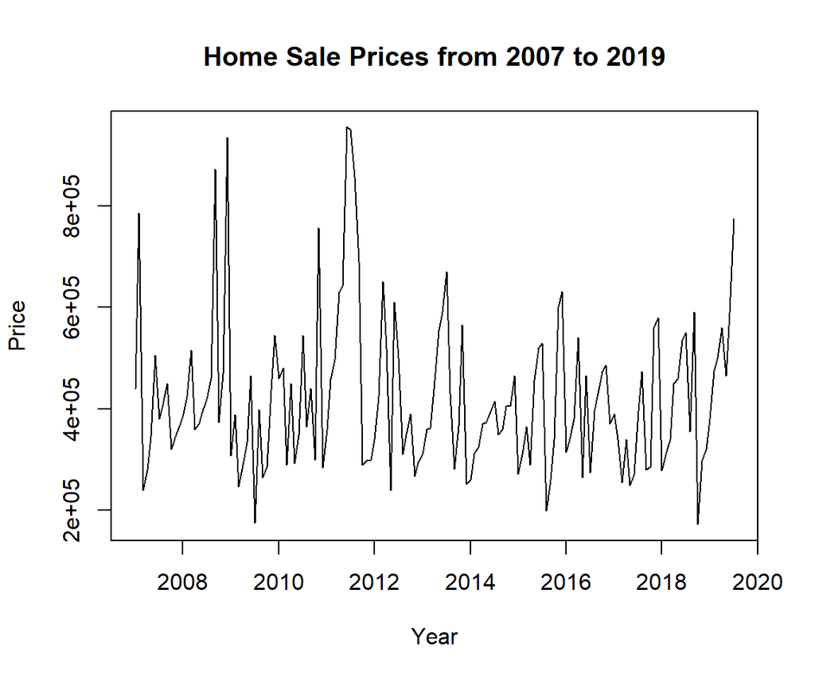

```r
home.ts = ts(data.home[,2], frequency = 12, start = c(2007, 1))
plot(home.ts, main="Home Sale Prices from 2007 to 2019", xlab = "Year", ylab = "Price")
```

As we can see in our plot, most of the house prices range between $200,000 and $800,000.

There does appear to be some sort of seasonal trend going on within the data as seen by the various peaks and drops that can be seen within the plot. This shows evidence of some sort of seasonality occurring. This could potentially be an annual or semi-annual seasonality, with the highest and lowest peaks occurring within the span of each year or half-year period.

A seasonal trend would make sense for a data set relating to house sale prices as the time of year could affect the number of individuals buying a new home, and thus sale prices rising to meet this larger demand. For instance, times of year such as the summer may see an increase of buyers looking for a new house due to the ideal weather and the timing of summer break making it ideal to buy a house before the next school year begins if the buyers have children. This greater demand could lead to a rise in the sales prices of the homes, and could be a potential explanation for this seasonal trend we see in the time series plot.

# 3 Forecasting with Classical Decomposing

First, let’s begin with looking at a classical decomposition of our time series data.

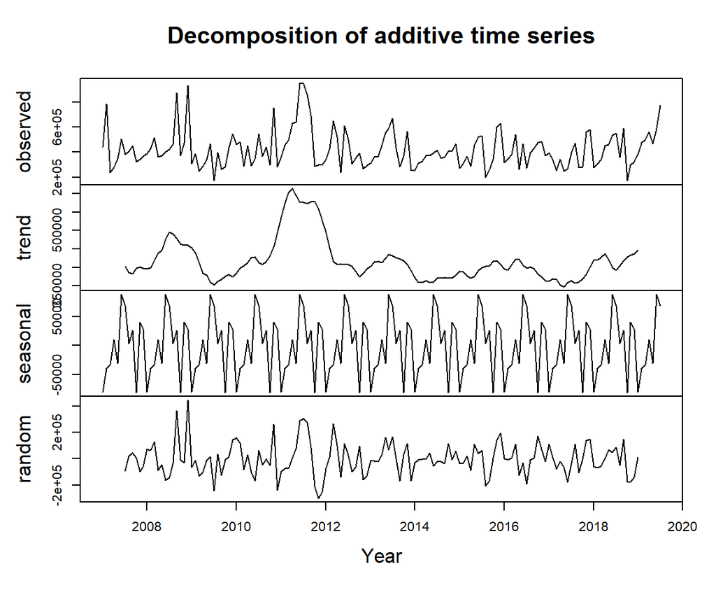

```r
# Classical Decomposition
cls.decomp = decompose(home.ts)
par(mar = c(2,2,2,2))
plot(cls.decomp, xlab = "Year")
```

In this visualization, we can see plots of the trend, seasonal, and random components. By looking at these plots, we can analyze the patterns of the time series of our data of house sale prices.

By looking at the trend component, we can see the overall pattern of house sale prices over the course of the years. It appears that all though there have been various phases of ups and downs, the house sale price at the start of the data in 2007 is fairly similar to the value at the very end of the data in 2019. Between the start and the end, however, there have been various shifts in house sale prices as evidenced by the various ups and downs in the trend curve. Most notably, there was a dramatically large rise in house sale prices around 2011 to 2012. This can also be seen in the observed curve as there is a notable peak in sales prices around this time period.

By looking at the seasonal component, we can see that this time series definitely does have seasonality to it. There appears to be a seasonal pattern which repeats at various points over the entire time which the data was collected. There is an overall, repeating cycle of prices experiencing rises and falls which continues multiple times over the course of the 12 year span which the data was collected. It appears that there may be an annual seasonality, as it appears like this repeating pattern may indeed match up with a one year period of the plot. This does match up with what was stated earlier when looking at the time series plot. An annual seasonal trend does make sense for a time series on house sale prices as there are likely times of the year, like summer, where more people would be interested in purchasing a new home. This greater demand would lead to a rise in sale prices, and then the sale prices would lower when there is less demand in times of the year where less individuals tend to purchase new houses, which reflects this seasonal pattern.

# 4 Forecasting with STL Decomposing

Next, let’s use STL decomposition on our time series data.

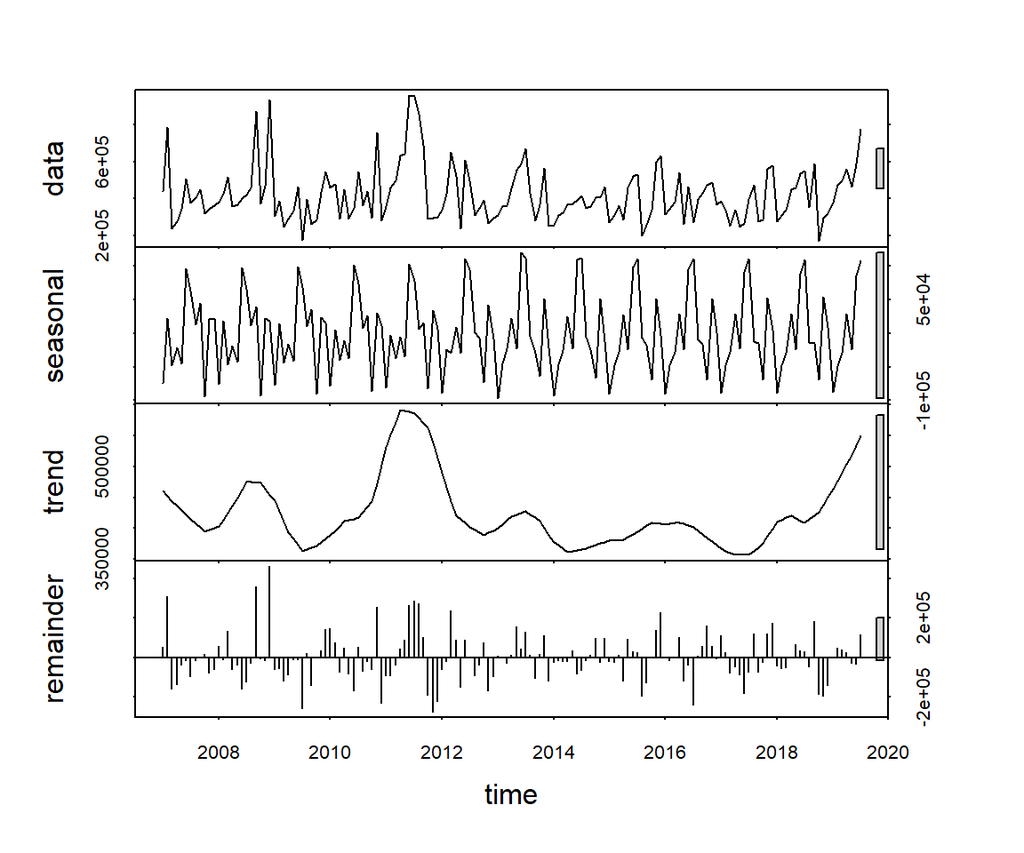

```r
# STL Decomposition
stl.decomp = stl(home.ts, s.window = 12)
par(mar = c(2,2,2,2))
plot(stl.decomp)
```

Using this STL decomposition method provides several advantages to the classical decomposition method we used previously. The STL decomposition method uses locally estimated scatterplot smoothing, also known as LOESS, to estimate non-linear trends with greater accuracy in its forecasting than using the classical decomposition would provide.

These plots created with the STL decomposition method allow us to observe some of the trends and patterns of our time series data. Overall, these plots generated by the STL decomposition provide similar findings to those created in the previous classical decomposition method. We see a similar overall trend, with various peaks and falls over the course of the data being collected from 2007 to 2019. We also see a similar seasonal pattern that repeats multiple times over the course of the time which the data was collected. This once again matches with the idea of an annual seasonality, as it appears like this seasonal pattern appears to repeat for each year that occurs. Also, similar to what was found in the classical decomposition method, is that there is a notable peak around 2011 to 2012 which shows the highest sales prices out of the entire data set. This peak around 2011 to 2012 is the highest overall sales prices which was observed throughout the time series window. These patterns found by the STL decomposition method match up with what was observed previously, and this STL decomposition method provides greater accuracy in its forecasting.

# 5 Training and Testing Data Sets

Next, let’s look into creating a training and a testing data set to forecast the time series model.

We will use the last seven observations to make up our testing data set, and we will try out four different potential sizes for the training data set. The four different sizes I will try out for the training data set are n = 100, n = 70, n= 50, and n = 35. This will be the number of observations which are used in the training data set.

```r
data = data.home[,2]
n0 = length(data)
train.data1 = data.home[43:(n0-7), 2]
train.data2 = data.home[73:(n0-7), 2]
train.data3 = data.home[93:(n0-7), 2]
train.data4 = data.home[108:(n0-7), 2]

# The testing data set will be the last 7 observations.
test.data = data.home[(n0-6):n0,2]

# Creating the four potential training data set sizes.
train1.ts = ts(train.data1, frequency = 12, start = c(2007, 1))
train2.ts = ts(train.data2, frequency = 12, start = c(2010, 1))
train3.ts = ts(train.data3, frequency = 12, start = c(2013, 1))
train4.ts = ts(train.data4, frequency = 12, start = c(2015, 1))

stl1 = stl(train1.ts, s.window = 12)
stl2 = stl(train2.ts, s.window = 12)
stl3 = stl(train3.ts, s.window = 12)
stl4 = stl(train4.ts, s.window = 12)
```

Next, let’s create the objects for forecasting.

```r
# Forecasting
fcst1 = forecast(stl1,h = 7, method = "naive")
fcst2 = forecast(stl2,h = 7, method = "naive")
fcst3 = forecast(stl3,h = 7, method = "naive")
fcst4 = forecast(stl4,h = 7, method = "naive")
```

We will perform error analysis to help us determine which size is best for the training data set out of the four potential sizes we are going to be choosing between. We will look at both the mean absolute prediction error (MAPE) and the mean squared error (MSE) of the potential training data sets.

```r
PE1 = (test.data-fcst1$mean)/fcst1$mean
PE2 = (test.data-fcst2$mean)/fcst2$mean
PE3 = (test.data-fcst3$mean)/fcst3$mean
PE4 = (test.data-fcst4$mean)/fcst4$mean

# Mean Absolute Prediction Errors.
MAPE1 = mean(abs(PE1))
MAPE2 = mean(abs(PE2))
MAPE3 = mean(abs(PE3))
MAPE4 = mean(abs(PE4))

E1 = test.data-fcst1$mean
E2 = test.data-fcst2$mean
E3 = test.data-fcst3$mean
E4 = test.data-fcst4$mean

# Mean Squared Errors.
MSE1 = mean(E1^2)
MSE2 = mean(E2^2)
MSE3 = mean(E3^2)
MSE4 = mean(E4^2)

MSE = c(MSE1, MSE2, MSE3, MSE4)
MAPE = c(MAPE1, MAPE2, MAPE3, MAPE4)
accuracy = cbind(MSE = MSE, MAPE = MAPE)
row.names(accuracy) = c("n = 100", "n = 70", "n = 50", "n = 35")
kable(accuracy, caption = "Error Comparison of the Forecast Results with Different Training Data Set Sizes")
```

Error Comparison of the Forecast Results with Different Training Data Set Sizes

|  | MSE | MAPE |
| --- | --- | --- |
| n = 100 | 65685377034 | 0.878393 |
| n = 70 | 93863039140 | 1.291822 |
| n = 50 | 109457437001 | 1.543327 |
| n = 35 | 110537492513 | 1.561396 |

As we can see, the training data set with a size of n = 100 has the lowest of both the MSE and the MAPE out of the four potential training data set sizes that were looked at. This suggests that this size is the most ideal out of the potential options as it reduces the errors the most out of the four options that were considered.

We will create a visualization to compare these forecast errors and confirm the finding that a sample size of 100 observations reduces the errors most out of the potential sample sizes that were considered for the training data set of the time series.

First, let’s look at a plot of the mean squared errors (MSE) for each of the four potential sample sizes.

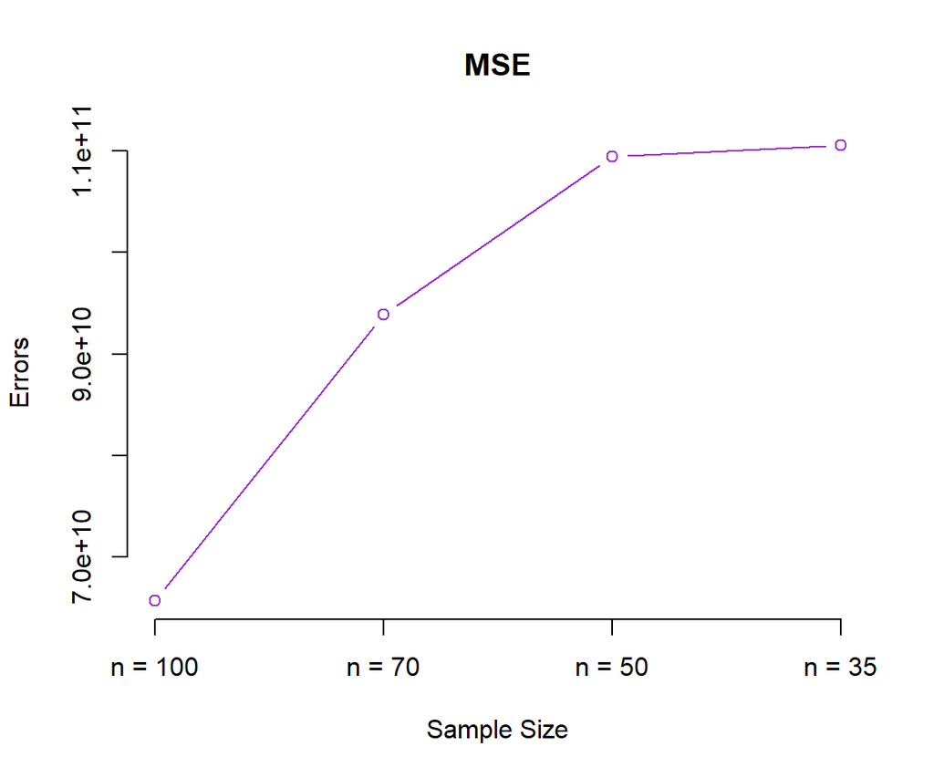

```r
# Plot of the MSE.
plot(1:4, MSE, type = "b", col="darkorchid", ylab = "Errors", xlab = "Sample Size",
     main = "MSE", axes = FALSE)
     labs = c("n = 100", "n = 70", "n = 50", "n = 35")
     axis(1, at = 1:4, label = labs)
     axis(2)
```

As we can see, n = 100 observations has the lowest MSE out of the four potential sample sizes, indicating that it is the ideal choice, because it reduces the errors.

We will also look at the plot of the mean absolute prediction errors (MAPE) for each of the four potential training data set sizes.

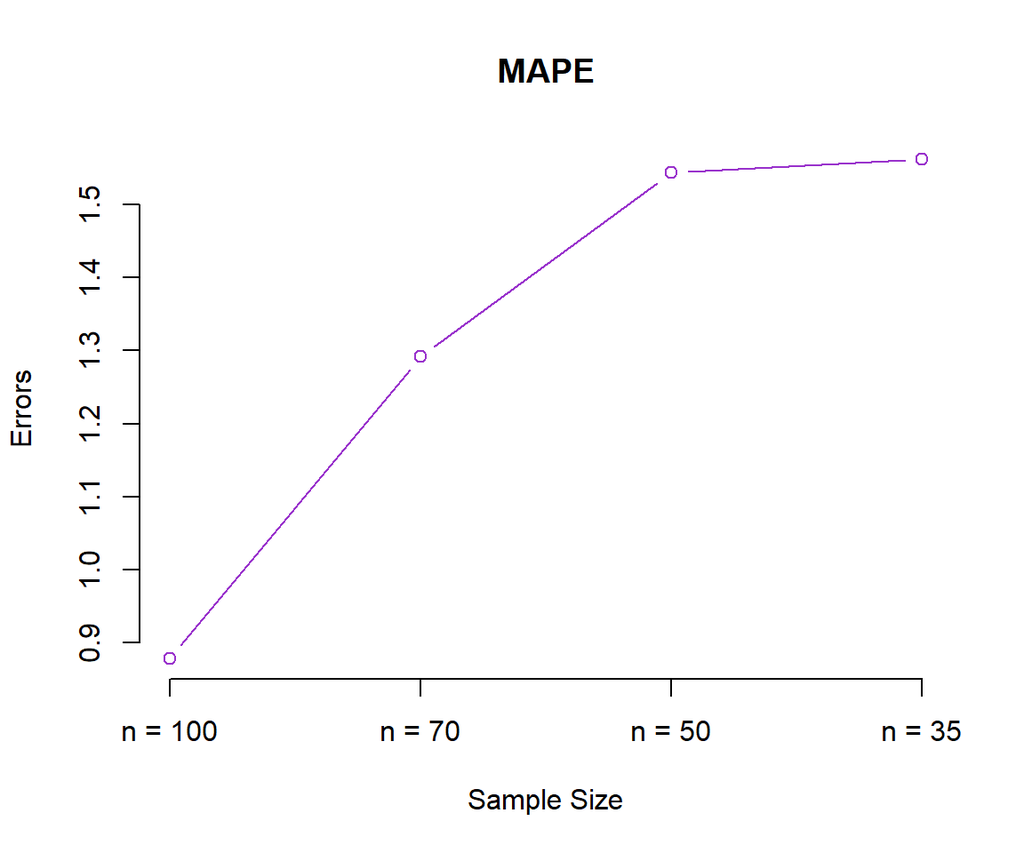

```r
# Plot of the MAPE.
plot(1:4, MAPE, type = "b", col="darkorchid", ylab = "Errors", xlab = "Sample Size",
     main = "MAPE", axes = FALSE)
     labs = c("n = 100", "n = 70", "n = 50", "n = 35")
     axis(1, at = 1:4, label = labs)
     axis(2)
```

Once again, the sample size of n = 100 observations shows the lowest value of the MAPE, showing that is the ideal choice out of the four sample sizes, because it reduces the errors.

As we can see in the plots for both the MSE and the MAPE, n = 100 observations shows the lowest errors, and as the sample size decreases in the number of observations, the errors for both the MSE and the MAPE increase, resulting in errors much greater than those of the sample size with 100 observations. This strengthens that the ideal training data set size out of the four options that were considered is a size of 100 observations. A training data set with 100 observations yields the best performance, because it reduces the errors.

So, we can conclude that from the choices of a training data set with 100, 70, 50, or 35 observations, the best choice is the training data set with 100 observations. This choice of 100 observations results in the lowest errors, and therefore, provides the best performance for forecasting our time series.

# 6 Conclusion

In this project, we created a time series of the home sales prices that were collected from the span of 2007 to 2019. We analyzed the trends and patterns of this time series to make note of any findings which stood out. One notable aspect of this time series was that it showed a seasonal pattern, with what looked like an annual seasonality. It was evident that there was a seasonal pattern of the home sales prices which repeated after a certain period of time. The time series plot showed that this pattern appeared to repeat on approximately an annual basis, with the home sales prices going through different phases of highs and lows over the course of each year. Both the classical decomposition method and the STL decomposition method confirmed the presence of this seasonal trend within the data for this time series of the home sales prices.

Additionally, we looked at four potential sample sizes to use for a training data set in order to determine which number of observations would be ideal to use. The four potential sizes for the training data set which we looked at were n = 100, 70, 50, and 35 observations. It turned out that the sample size of n = 100 observations was the ideal choice out of these four options, because it resulted in the lowest errors, as seen by how it had the lowest values for both its MSE and its MAPE. This indicates that the sample size of 100 observations provides the best utility for the training set, because it reduces the errors.

## 6.1 Recommendations

Some recommendations I would make for future projects include:

- Overall, it appeared like there was an annual seasonality in this particular time series done on the observed values of the sales prices of houses over the span of 2007 to 2019. Some potential reasons were given to provide an explanation for this seasonal trend, such as more individuals buying houses in the summer leading the an increase in sales prices. To further strengthen the evidence of this seasonal trend, future projects could look further into this to see if this is indeed a common pattern with records of house sales prices.
- Future projects could look into trying out even more different training data set sizes to see if there is another one which would work even better than the ones that we tried out in this project. We looked at four potential sizes for the training data set to see which one provided the best accuracy, and found that n = 100 observations provided the best utility by reducing the errors. However, perhaps future projects could try out even more different sizes to see if there is one which provides even better accuracy by reducing the errors.

Overall, this time series projects provided insight into some of the patterns and trends surrounding the house sale prices from the span of time from 2007 to 2019. The seasonality and trends which were observed show that the sales prices of houses is something which goes through cycles of changes, and various highs and lows throughout the span of time.

# 7 References

The data set I used for my time series was found on kaggle.com. Included below is the citation of the web page where I found this data set.

Holdings, H., & James, T. (2019, August 12). House Property Sales Time Series. Kaggle. https://www.kaggle.com/datasets/htagholdings/property-sales/data